# Assignment 4: Spatial Predictive Analysis

Author

Katie Knox

Published

November 16, 2025

## Part 1: Collect 311 Violation Data

I have chosen to look at “All street lights out” violations, because it is more cozy to commit crimes when the lights are out.

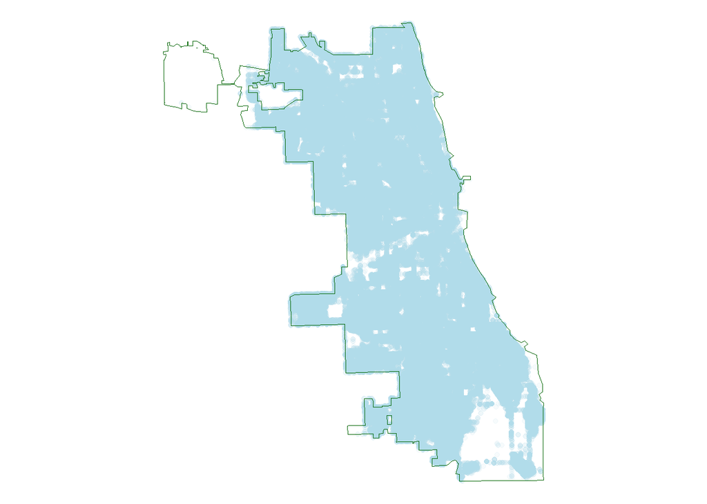

```r
chi_boundary<-chi_boundary%>%st_transform(st_crs(all_lights_out))

chi_boundary<-chi_boundary%>%st_transform(26971)
all_lights_out<-all_lights_out%>%st_transform(26971)

all_lights_out%>%
  ggplot()+
  geom_sf(alpha = 0.1, color = "lightblue")+
  geom_sf(data = chi_boundary, fill = NA, color = "darkgreen")+
  theme_void()
```

The 311 complaints of all street lights out are seemingly very ubiquitous across Chicago! Every part of the city is very visual dense with instances. The only empty areas are where the airport is located, and where there are bodies of water and parks.

## Part 2: Fishnet Grid

```r
# Step 1: Define cell size (in map units - meters for this projection)
cell_size <- 500  # 500m x 500m cells

# Step 2: Create grid over study area
fishnet <- st_make_grid(
  chi_boundary,
  cellsize = cell_size,
  square = TRUE,
  what = "polygons"
) %>%
  st_sf() %>%
  mutate(uniqueID = row_number())

# Step 3: Clip to study area (remove cells outside boundary)
fishnet <- fishnet[chi_boundary, ]

# Check results
nrow(fishnet)  # Number of cells
```

```
[1] 2640
```

```r
st_area(fishnet[1, ])  # Area of one cell (should be 250,000 m²)
```

```
250000 [m^2]
```

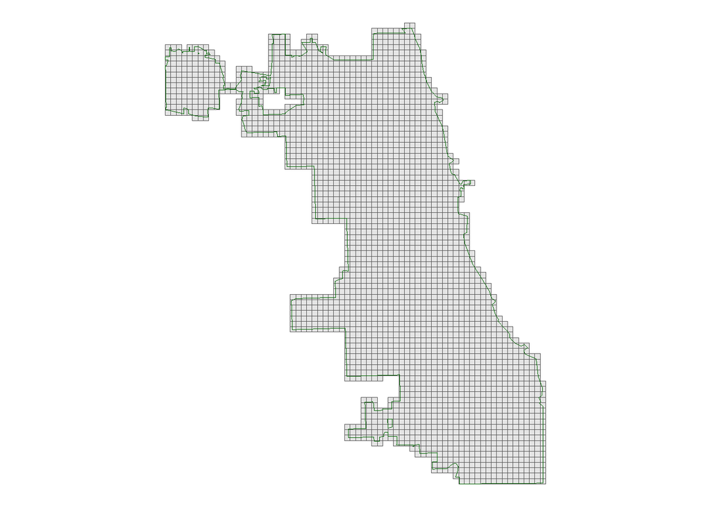

```r
fishnet %>%
  ggplot()+
  geom_sf()+
  geom_sf(data = chi_boundary, fill=NA, color="darkgreen")+
  theme_void()
```

```r
# Count lights out per cell
lights_out_count <- st_join(all_lights_out, fishnet) %>%
  st_drop_geometry() %>%
  group_by(uniqueID) %>%
  summarize(count = n())

# Join back to fishnet
fishnet <- fishnet %>%
  left_join(lights_out_count, by = "uniqueID") %>%
  mutate(count_lights_out = replace_na(count, 0))

# Summary
summary(fishnet$count_lights_out)
```

```
   Min. 1st Qu.  Median    Mean 3rd Qu.    Max.
    0.0    24.0    95.5   112.3   167.0   673.0
```

## Part 3: Spatial Features

Find “Nearest Neighbor”

```r
# Calculate distance to nearest complaint of all street lights out
nn_dist <- get.knnx(
  data = st_coordinates(all_lights_out),      # "To" locations
  query = st_coordinates(st_centroid(fishnet)), # "From" locations
  k = 1                                          # Nearest 1
)

# Extract distances
fishnet$lights_out_dists <- nn_dist$nn.dist[, 1]
summary(fishnet$lights_out_dists)
```

```
     Min.   1st Qu.    Median      Mean   3rd Qu.      Max.
   0.9545   33.3966   54.0120  194.0979  124.7172 4603.3141
```

The median distance from a random 500x500 area in Chicago to a reported incident of all street lights out is 54 meters, and the 3rd quantile is 124 meters. This means the majority of ares in Chicago are very near one such complaint (and likely more than one given the distribution of incident counts per grid cell from the previous step). The mean is higher that the 3rd quantile, showing that max distance is an extreme outlier, likely in one of the park or airport areas where there probably aren’t streets in a park let alone street lights.

Find Local Moran’s I

```r
# Step 1: Create spatial object
fishnet_sp <- as_Spatial(fishnet)

# Step 2: Define neighbors (Queen contiguity)
neighbors <- poly2nb(fishnet_sp, queen = TRUE)

# Step 3: Create spatial weights (row-standardized)
weights <- nb2listw(neighbors, style = "W", zero.policy = TRUE)

# Step 4: Calculate Local Moran's I
local_moran <- localmoran(
  fishnet$count_lights_out,  # Variable of interest
  weights,                  # Spatial weights
  zero.policy = TRUE       # Handle cells with no neighbors
)

# Step 5: Extract components
fishnet$local_I <- local_moran[, "Ii"]      # Local I statistic
fishnet$p_value <- local_moran[, "Pr(z != E(Ii))"]  # P-value
fishnet$z_score <- local_moran[, "Z.Ii"]    # Z-score
```

```r
# Standardize the variable for quadrant classification
fishnet$standardized_value <- scale(fishnet$count_lights_out)

# Calculate spatial lag (weighted mean of neighbors)
fishnet$spatial_lag <- lag.listw(weights, fishnet$count_lights_out)
fishnet$standardized_lag <- scale(fishnet$spatial_lag)

# Identify High-High clusters
fishnet$hotspot <- 0  # Default: not a hotspot

# Criteria:
# 1. Value above mean (standardized > 0)
# 2. Neighbors above mean (spatial lag > 0)
# 3. Statistically significant (p < 0.05)

fishnet$hotspot[
  fishnet$standardized_value > 0 &
  fishnet$standardized_lag > 0 &
  fishnet$p_value < 0.05
] <- 1

# Count hotspots
sum(fishnet$hotspot)
```

```
[1] 418
```

In this step, first each cell’s count of incidents is standardized to measure how much it deviates from the mean, and a spatial lag is calculated to summarize the average counts in neighboring cells based on the intution that areas with high incident counts tend to be near other areas with high counts, so clustering in space can reveal meaningful hotspots of activity. Cells are classified as High-High clusters (hotspots) if they have above-average counts, are surrounded by neighbors with above-average counts, and are statistically significant based on Local Moran’s I (p < 0.05). The fact that the sum of hotspots is 418 indicates that 418 grid cells are part of statistically significant clusters of high incident density.

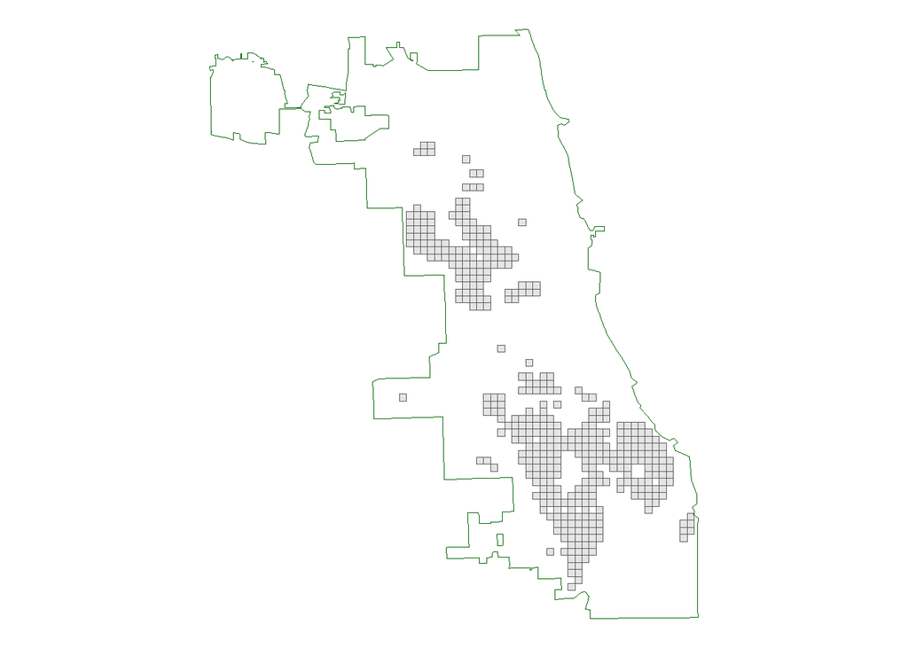

```r
fishnet%>%filter(hotspot==1)%>%
  ggplot()+
  geom_sf()+
  theme_void()+
  geom_sf(data = chi_boundary, fill = NA, color = "darkgreen")
```

Looking at a map of these hotspots reveals they are concentrated in areas west and south of the main center city core.

Next, I find distance of each grid cell to hotspot.

```r
# Step 1: Identify hotspots
hotspot_cells <- filter(fishnet, hotspot == 1)

# Step 2: Calculate distances
hotspot_dist <- get.knnx(
  data = st_coordinates(st_centroid(hotspot_cells)),
  query = st_coordinates(st_centroid(fishnet)),
  k = 1
)

fishnet$hotspot_nn <- hotspot_dist$nn.dist[, 1]
```

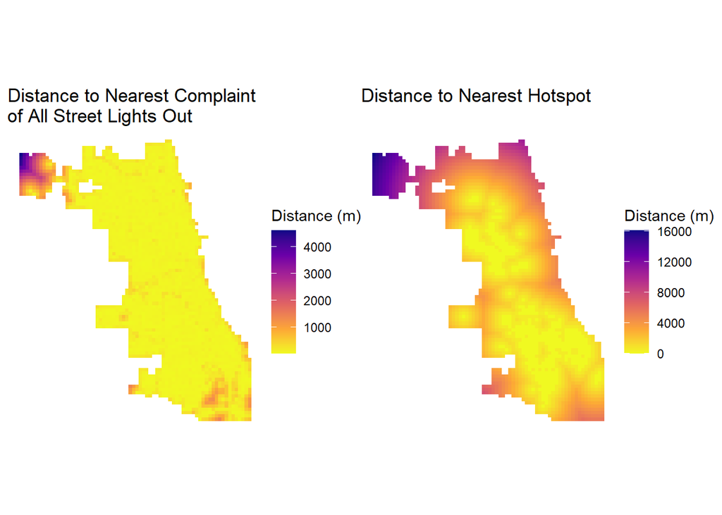

```r
# Create comparison maps
p1 <- ggplot(fishnet) +
  geom_sf(aes(fill = lights_out_dists), color = NA) +
  scale_fill_viridis_c(name = "Distance (m)", option = "plasma",  direction = -1) +
  labs(title = "Distance to Nearest Complaint\nof All Street Lights Out") +
  theme_void()


p2 <- ggplot(fishnet) +
  geom_sf(aes(fill = hotspot_nn), color = NA) +
  scale_fill_viridis_c(name = "Distance (m)", option = "plasma",  direction = -1) +
  labs(title = "Distance to Nearest Hotspot") +
  theme_void()

p1 + p2 + plot_layout(ncol = 2)
```

## Part 4: Count Regression Models

Collect crimes data and join crime counts to fishnet

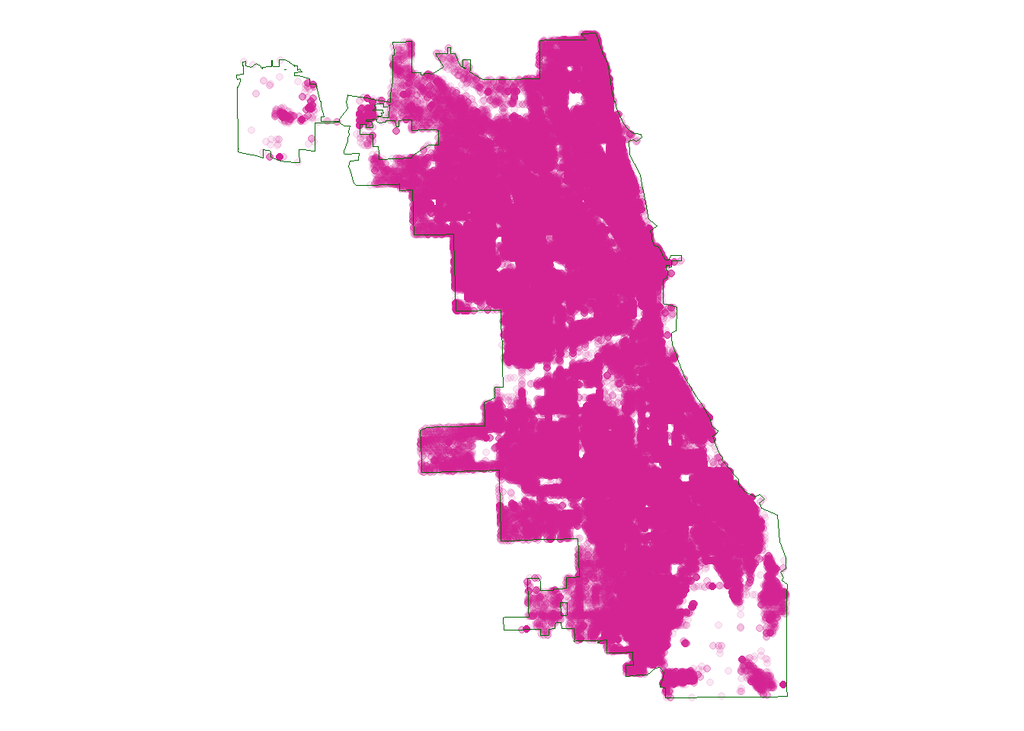

```r
crimes <- read.csv("C:/Users/knoxk/Downloads/Crimes_-_2018_20251117.csv")
crimes <- crimes%>%filter(!is.na(Latitude) & !is.na(Longitude))
crimes_sf <- crimes %>% st_as_sf(coords = c("Longitude", "Latitude"), crs = 4326)
crimes_sf <- crimes_sf %>% st_transform(26971)

crimes_sf%>%
  ggplot()+
  geom_sf(alpha = 0.1, color = "violetred")+
  geom_sf(data = chi_boundary, fill = NA, color = "darkgreen")+
  theme_void()
```

```r
# Count lights out per cell
crime_count <- st_join(crimes_sf, fishnet) %>%
  st_drop_geometry() %>%
  group_by(uniqueID) %>%
  summarize(crime_count = n())

# Join back to fishnet
fishnet <- fishnet %>%
  left_join(crime_count, by = "uniqueID") %>%
  mutate(crime_count = replace_na(crime_count, 0))

# Summary
summary(fishnet$crime_count)
```

```
   Min. 1st Qu.  Median    Mean 3rd Qu.    Max.
   0.00   11.00   60.00   99.82  136.00 2188.00
```

This shows the distribution of crimes per fishnet grid.

```r
# Fit Poisson model
model_poisson <- glm(
  crime_count ~ count_lights_out + lights_out_dists,
  data = fishnet,
  family = poisson(link = "log")
)

# View results
summary(model_poisson)
```

```
Call:
glm(formula = crime_count ~ count_lights_out + lights_out_dists,
    family = poisson(link = "log"), data = fishnet)

Coefficients:
                   Estimate Std. Error z value Pr(>|z|)
(Intercept)       4.436e+00  4.602e-03   963.9   <2e-16 ***
count_lights_out  3.404e-03  1.706e-05   199.5   <2e-16 ***
lights_out_dists -3.982e-03  3.557e-05  -111.9   <2e-16 ***
---
Signif. codes:  0 '***' 0.001 '**' 0.01 '*' 0.05 '.' 0.1 ' ' 1

(Dispersion parameter for poisson family taken to be 1)

    Null deviance: 351602  on 2639  degrees of freedom
Residual deviance: 231205  on 2637  degrees of freedom
AIC: 244686

Number of Fisher Scoring iterations: 9
```

```r
# Exponentiate coefficients for interpretation
exp(coef(model_poisson))
```

```
     (Intercept) count_lights_out lights_out_dists
      84.4003005        1.0034096        0.9960263
```

Using a Poisson Regression where the dependent variable is the number of crimes in a grid cell and the dependent variables are the count of complaints of lights out and distance from grid center to nearest complaint of lights out. The model shows that areas with more “lights out” complaints tend to have slightly higher crime counts. Specifically, each additional street light reported as out in a grid cell is associated with a small increase in the expected number of crimes. Conversely, the farther a location is from the nearest street light outage, the slightly lower the expected crime count. In other words, crimes tend to be more common in areas where street lights are out or clustered, suggesting a very very small link between lighting conditions and crime risk.

```r
# Calculate dispersion parameter
model_pois <- glm(
  crime_count ~ count_lights_out + lights_out_dists,
  data = fishnet,
  family = poisson
)

dispersion <- sum(residuals(model_pois, type = "pearson")^2) / model_pois$df.residual

cat("Dispersion parameter:", round(dispersion, 3), "\n")
```

```
Dispersion parameter: 19091.61
```

This dispersion is quite enormous, and shows that the variance is significantly higher than the mean, which violates an assumption of the Poisson Model.

```r
# Fit Negative Binomial model
model_nb <- glm.nb(
  crime_count ~ count_lights_out + lights_out_dists,
  data = fishnet,
  init.theta = 1,      # starting value for dispersion
  control = glm.control(epsilon = 1e-8, maxit = 50)
)

# View results
summary(model_nb)
```

```
Call:
glm.nb(formula = crime_count ~ count_lights_out + lights_out_dists,
    data = fishnet, control = glm.control(epsilon = 1e-08, maxit = 50),
    init.theta = 0.6218860388, link = log)

Coefficients:
                   Estimate Std. Error z value Pr(>|z|)
(Intercept)       3.563e+00  4.293e-02   82.99   <2e-16 ***
count_lights_out  7.790e-03  2.596e-04   30.01   <2e-16 ***
lights_out_dists -7.746e-04  6.132e-05  -12.63   <2e-16 ***
---
Signif. codes:  0 '***' 0.001 '**' 0.01 '*' 0.05 '.' 0.1 ' ' 1

(Dispersion parameter for Negative Binomial(0.6219) family taken to be 1)

    Null deviance: 4221.3  on 2639  degrees of freedom
Residual deviance: 3197.0  on 2637  degrees of freedom
AIC: 27647

Number of Fisher Scoring iterations: 1

              Theta:  0.6219
          Std. Err.:  0.0168

 2 x log-likelihood:  -27638.6580
```

```r
# Compare to Poisson
AIC(model_poisson)
```

```
[1] 244685.8
```

```r
AIC(model_nb)
```

```
[1] 27646.66
```

A Negative Binomial model is a type of count regression that estimates the relationship between predictor variables and a count outcome while accounting for overdispersion, making it appropriate when the variance of the counts exceeds the mean, as is the case here.

Each additional street light reported as out is associated with an approximately 0.78% increase in expected crime counts, while each additional meter further from the nearest lights-out complaint is associated with an approximately 0.08% decrease. These effects are statistically significant, though quite small in magnitude, and the negative binomial model accounts for overdispersion in crime counts, providing more reliable estimates than the Poisson Model. This is supported by the NB model’s much lower AIC.